# Univariate TS Models (ARIMA/SARIMA)s

# Forecaseting

**Total TEUs**

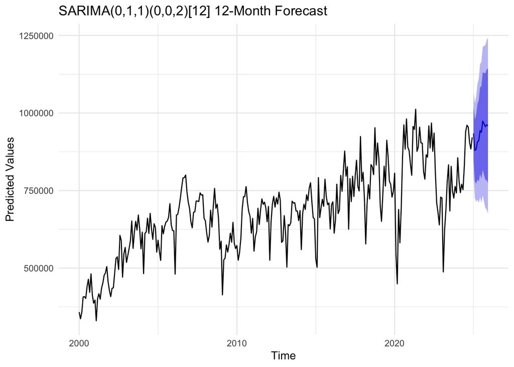

```r
fit <- Arima(la_teu_ts, order = c(0,1,1), seasonal = list(order = c(0,0,2), period = 12))
forecast_result <- forecast(fit, h = 12)
autoplot(forecast_result) +
  labs(title = "SARIMA(0,1,1)(0,0,2)[12] 12-Month Forecast",
       x = "Time",
       y = "Predicted Values") +
  theme_minimal()
```

The SARIMA(0,1,1)(0,0,2)[12] model captures both the seasonal and short-term variations in total container throughput. The fitted line closely follows the historical pattern, indicating that the model effectively reflects annual fluctuations in port activity. The 12-month-ahead forecast shows a moderate upward trend with widening confidence intervals, reflecting the growing uncertainty as the forecast horizon extends.

**Loaded Imports**

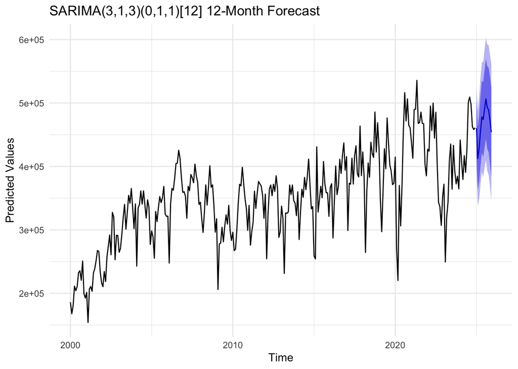

```r
fit <- Arima(la_li_ts, order = c(3,1,3), seasonal = list(order = c(0,1,1), period = 12))
forecast_result <- forecast(fit, h = 12)
autoplot(forecast_result) +
  labs(title = "SARIMA(3,1,3)(0,1,1)[12] 12-Month Forecast",
       x = "Time",
       y = "Predicted Values") +
  theme_minimal()
```

The SARIMA(3,1,3)(0,1,1)[12] model provides a strong fit to the historical import series, successfully accounting for both seasonality and irregular changes. The model indicates that import volumes are likely to remain relatively stable, with mild cyclical movements during the next year. The shaded blue area represents the forecast confidence intervals, which gradually widen over time, suggesting increasing uncertainty in long-term predictions.

**Loaded Exports**

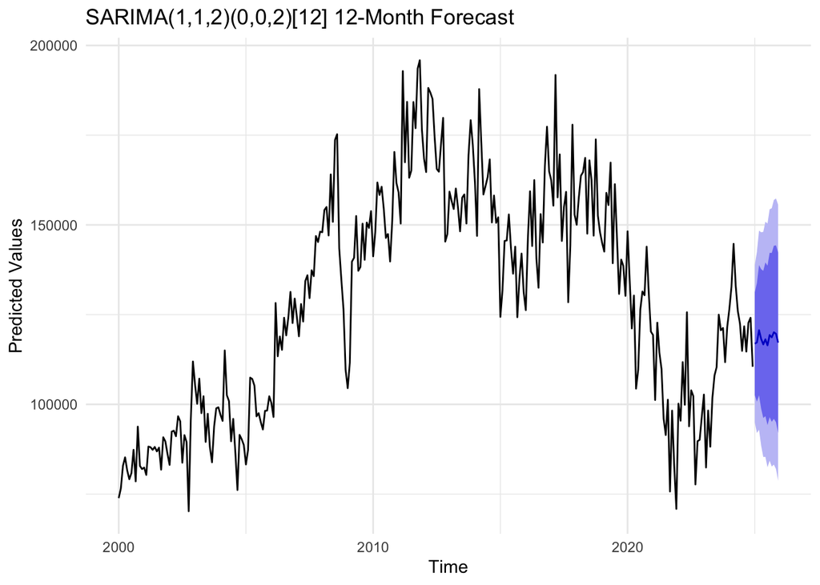

```r
fit <- Arima(la_le_ts, order = c(1,1,2), seasonal = list(order = c(0,0,2), period = 12))
forecast_result <- forecast(fit, h = 12)
autoplot(forecast_result) +
  labs(title = "SARIMA(1,1,2)(0,0,2)[12] 12-Month Forecast",
       x = "Time",
       y = "Predicted Values") +
  theme_minimal()
```

The SARIMA(1,1,2)(0,0,2)[12] model demonstrates a reasonable fit for the export time series. The 12-month forecast suggests a relatively steady export trend following recent recoveries from previous downturns. The confidence intervals expand toward the end of the horizon, indicating greater uncertainty in later forecasts.

**Brent Crude Oil Price**

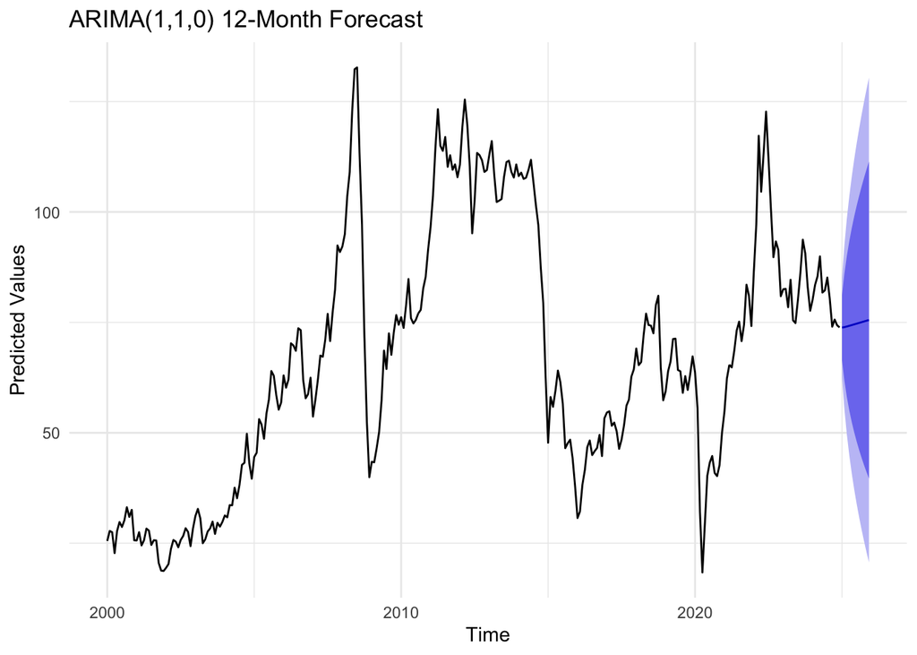

```r
fit <- Arima(brent_ts, order = c(1,1,0), include.drift = TRUE)
forecast_result <- forecast(fit, h = 12)
autoplot(forecast_result) +
  labs(title = "ARIMA(1,1,0) 12-Month Forecast",
       x = "Time",
       y = "Predicted Values") +
  theme_minimal()
```

The ARIMA(1,1,0) model provides a parsimonious yet effective representation of the Brent Crude Oil Price series. The fitted model captures the major trend shifts and volatility observed over the past two decades, including sharp rises and downturns. The 12-month forecast suggests that oil prices may stabilize in the near term, with a relatively wide confidence band reflecting the inherent volatility of the energy market.

**U.S. Dollar Index**

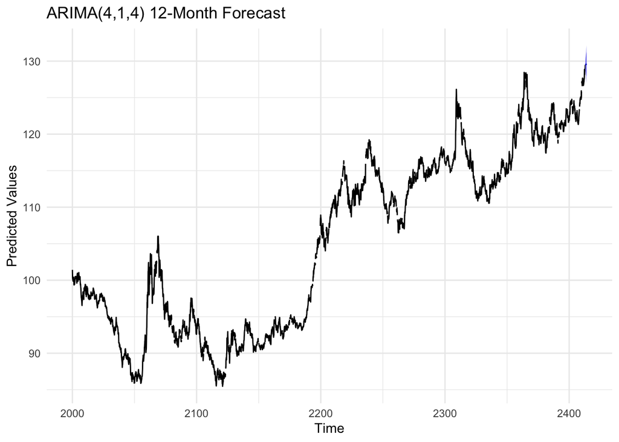

```r
fit <- Arima(usd_ts, order = c(4,1,4), include.drift = TRUE)
forecast_result <- forecast(fit, h = 12)
autoplot(forecast_result) +
  labs(title = "ARIMA(4,1,4) 12-Month Forecast",
       x = "Time",
       y = "Predicted Values") +
  theme_minimal()
```

The ARIMA(4,1,4) model fits the U.S. Dollar Index series well, capturing its long-term cycles and short-term fluctuations. The model indicates a gradual strengthening of the dollar over the forecast horizon, consistent with the recent upward momentum observed in historical data. The narrow confidence intervals suggest relatively high model certainty for short-term projections, though external macroeconomic factors may introduce additional variability.

**Global Supply Chain Pressure Index**

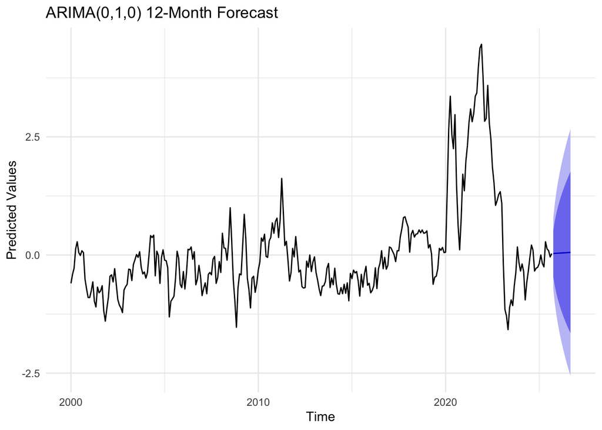

```r
fit <- Arima(gscpi_ts, order = c(0,1,0), include.drift = TRUE)
forecast_result <- forecast(fit, h = 12)
autoplot(forecast_result) +
  labs(title = "ARIMA(0,1,0) 12-Month Forecast",
       x = "Time",
       y = "Predicted Values") +
  theme_minimal()
```

**AHS Weighted Average Tariff**

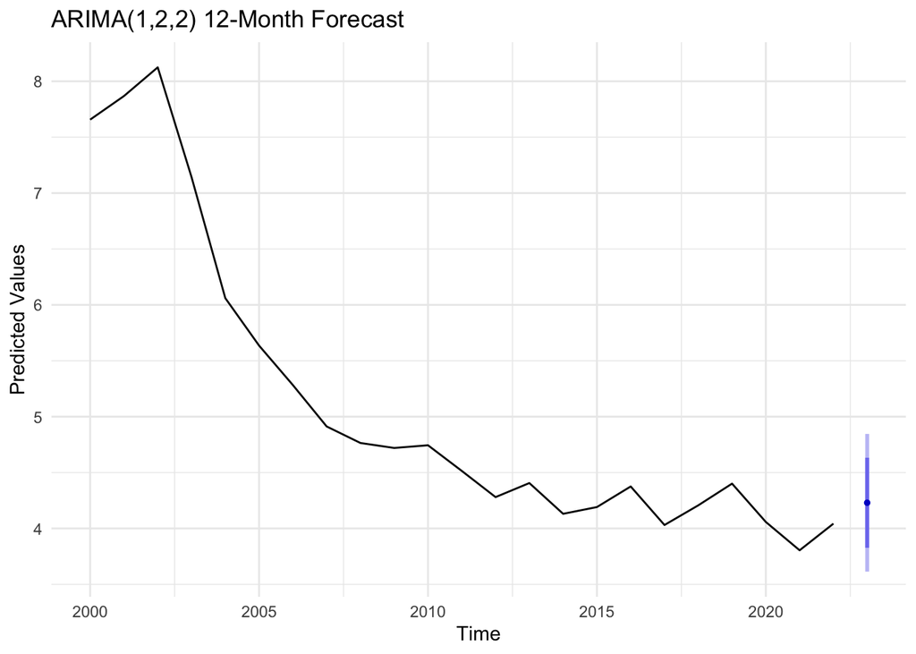

```r
fit <- Arima(ahs_ts, order = c(1,2,2), include.drift = TRUE)
forecast_result <- forecast(fit, h = 1)
autoplot(forecast_result) +
  labs(title = "ARIMA(1,2,2) 12-Month Forecast",
       x = "Time",
       y = "Predicted Values") +
  theme_minimal()
```

The ARIMA(1,2,2) model fits the AHS Weighted Average Tariff series appropriately, capturing its long-term downward trend. The results show that global tariff levels have steadily declined since the early 2000s, reflecting progressive trade liberalization and tariff reduction policies. The short forecast horizon remains relatively flat, suggesting tariff rates are expected to stabilize at their current low levels in the near future.

**S&P 500 Index**

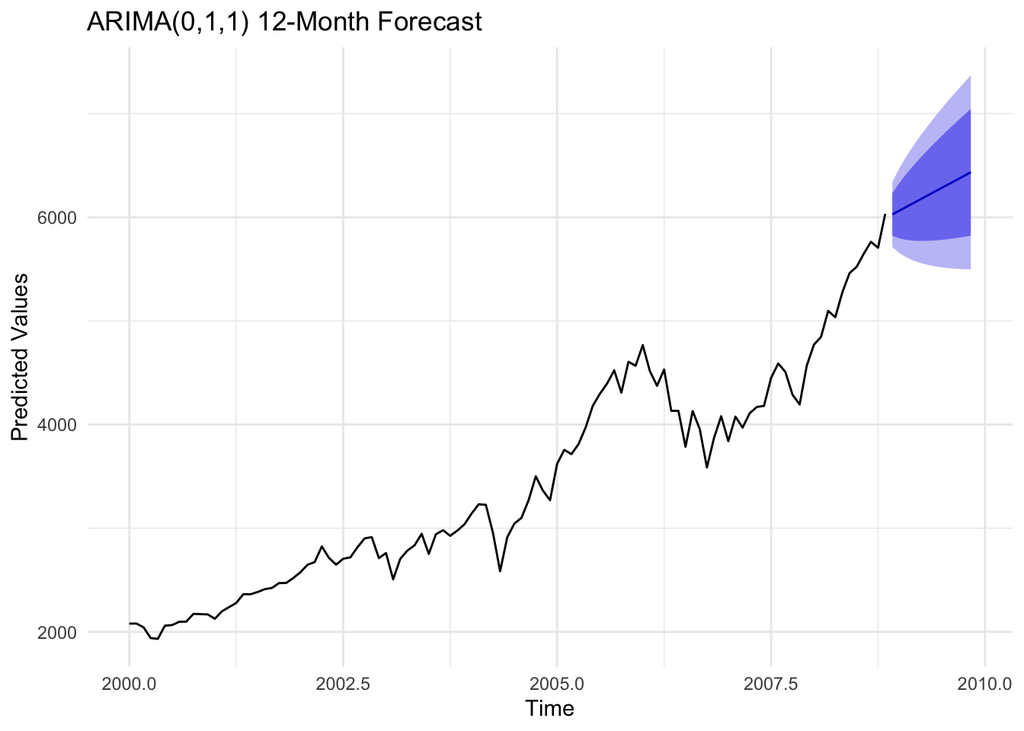

```r
fit <- Arima(sp500_ts, order = c(0,1,1), include.drift = TRUE)
forecast_result <- forecast(fit, h = 12)
autoplot(forecast_result) +
  labs(title = "ARIMA(0,1,1) 12-Month Forecast",
       x = "Time",
       y = "Predicted Values") +
  theme_minimal()
```

**U.S. Retail & Food Services Sales**

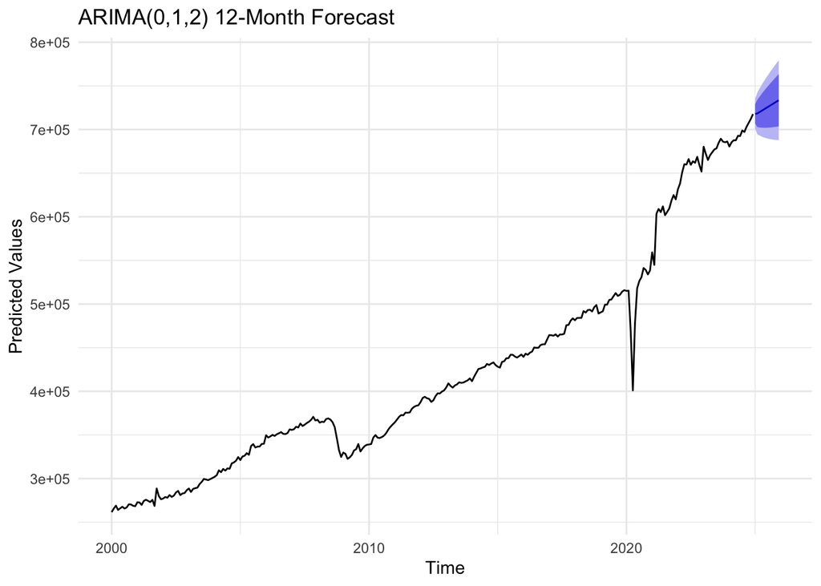

```r
fit <- Arima(rsafs_ts, order = c(0,1,2), include.drift = TRUE)
forecast_result <- forecast(fit, h = 12)
autoplot(forecast_result) +
  labs(title = "ARIMA(0,1,2) 12-Month Forecast",
       x = "Time",
       y = "Predicted Values") +
  theme_minimal()
```

The ARIMA(0,1,2) model captures the strong upward trend and cyclical fluctuations in U.S. Retail & Food Services Sales. The model effectively reflects the steady expansion of consumer spending over the past two decades, with only temporary disruptions during major economic downturns, such as the 2008 financial crisis and the 2020 pandemic shock. The 12-month forecast continues this growth trajectory, suggesting stable consumer demand and sustained economic resilience, while the widening confidence intervals indicate moderate uncertainty in long-term consumption trends.

# Comparison with Benchmark Methods

```r
plot_forecasts <- function(forecast_result, ts, h, fit) {
  print(accuracy(forecast_result))
  # Plot the forecasts using Mean, Naïve, Drift Methods, and ARIMA Fit
  autoplot(ts) +
    autolayer(meanf(ts, h = h), series = "Mean", PI = FALSE) +
    autolayer(naive(ts, h = h), series = "Naïve", PI = FALSE) +
    autolayer(snaive(ts, h = h), series = "SNaïve", PI = FALSE) +
    autolayer(rwf(ts, drift = TRUE, h = h), series = "Drift", PI = FALSE) +
    autolayer(forecast(fit, h = h), series = "Fit", PI = FALSE) +
    xlab("Date") +
    ylab("Predicted Values") +
    guides(colour = guide_legend(title = "Forecast Methods")) +
    theme_minimal()
}
```

**Total TEUs**

```
                   ME     RMSE      MAE        MPE     MAPE      MASE
Training set 2698.941 66959.14 50162.95 -0.2932804 7.616376 0.6359643
                    ACF1
Training set 0.007051023
```

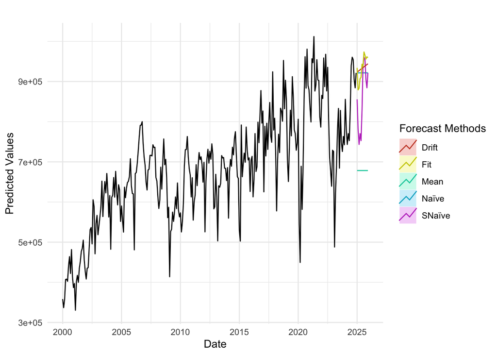

```r
fit <- Arima(la_teu_ts, order = c(0,1,1), seasonal = list(order = c(0,0,2), period = 12))
forecast_result <- forecast(fit, h = 12)
plot_forecasts(forecast_result, la_teu_ts, 12, fit)
```

**Loaded Imports**

```
                    ME     RMSE      MAE       MPE     MAPE      MASE
Training set -1028.271 32361.58 22702.52 -1.060353 6.637611 0.5172492
                     ACF1
Training set -0.006157007
```

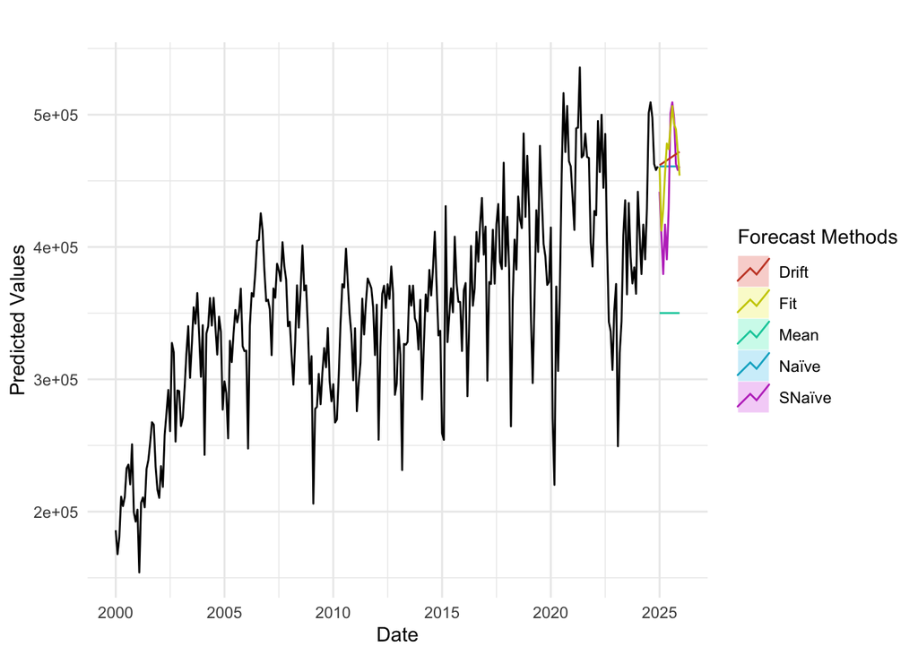

```r
fit <- Arima(la_li_ts, order = c(3,1,3), seasonal = list(order = c(0,1,1), period = 12))
forecast_result <- forecast(fit, h = 12)
plot_forecasts(forecast_result, la_li_ts, 12, fit)
```

**Loaded Exports**

```
                   ME     RMSE      MAE        MPE     MAPE      MASE
Training set 343.4435 11070.48 8411.059 -0.2564297 6.677604 0.5242162
                     ACF1
Training set -0.008348581
```

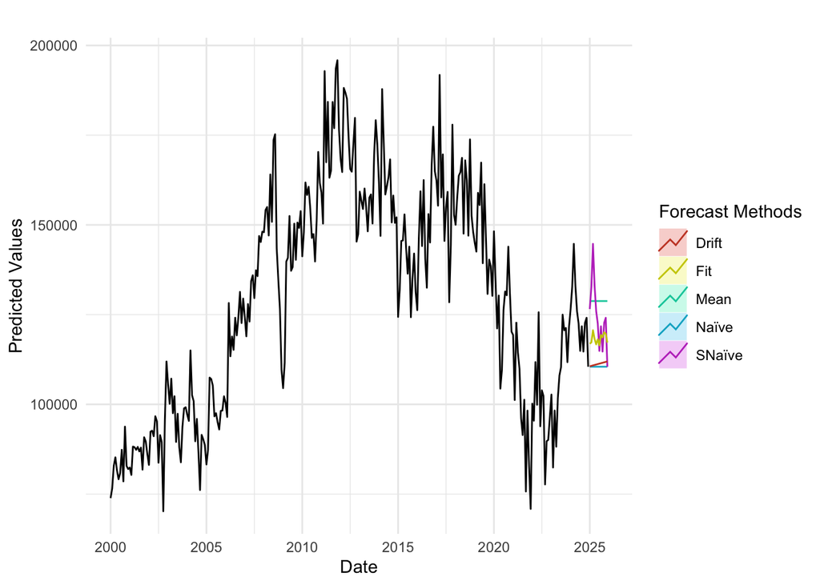

```r
fit <- Arima(la_le_ts, order = c(1,1,2), seasonal = list(order = c(0,0,2), period = 12))
forecast_result <- forecast(fit, h = 12)
plot_forecasts(forecast_result, la_le_ts, 12, fit)
```

**Brent Crude Oil Price**

```
                       ME     RMSE      MAE        MPE     MAPE      MASE
Training set -0.002483961 5.755968 4.400178 -0.2521299 7.395091 0.2461404
                   ACF1
Training set 0.01959034
```

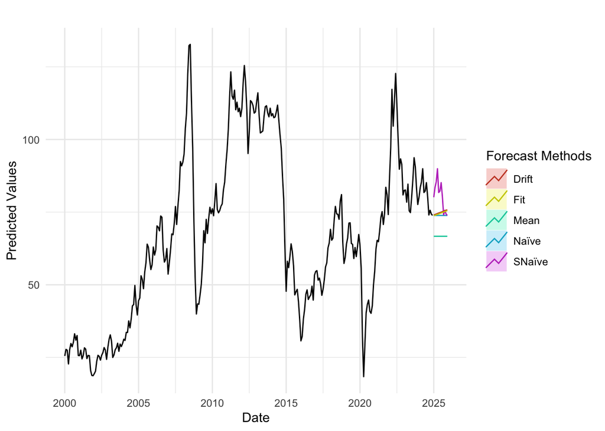

```r
fit <- Arima(brent_ts, order = c(1,1,0), include.drift = TRUE)
forecast_result <- forecast(fit, h = 12)
plot_forecasts(forecast_result, brent_ts, 12, fit)
```

**U.S. Dollar Index**

```
                        ME      RMSE       MAE          MPE      MAPE      MASE
Training set -0.0009317316 0.3554529 0.2554455 -0.001885219 0.2428921 0.2647159
                     ACF1
Training set 0.0009468745
```

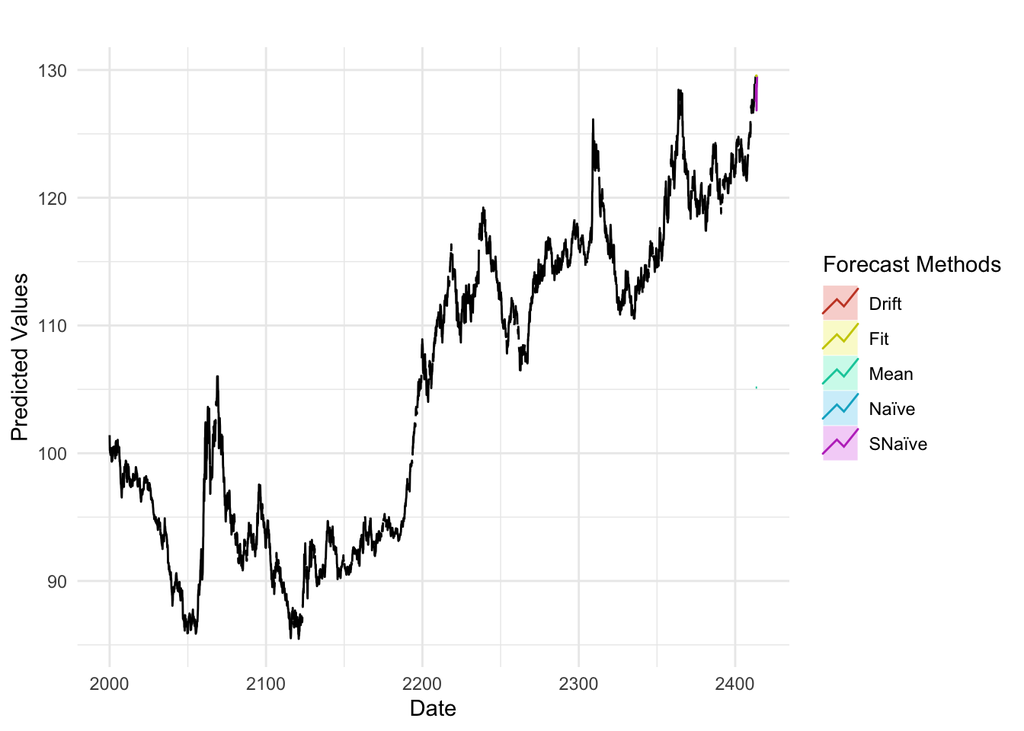

```r
fit <- Arima(usd_ts, order = c(4,1,4), include.drift = TRUE)
forecast_result <- forecast(fit, h = 12)
plot_forecasts(forecast_result, usd_ts, 12, fit)
```

**Global Supply Chain Pressure Index**

```
                        ME      RMSE       MAE MPE MAPE    MASE       ACF1
Training set -1.948366e-06 0.3834042 0.2892091 Inf  Inf 0.39396 0.08373419
```

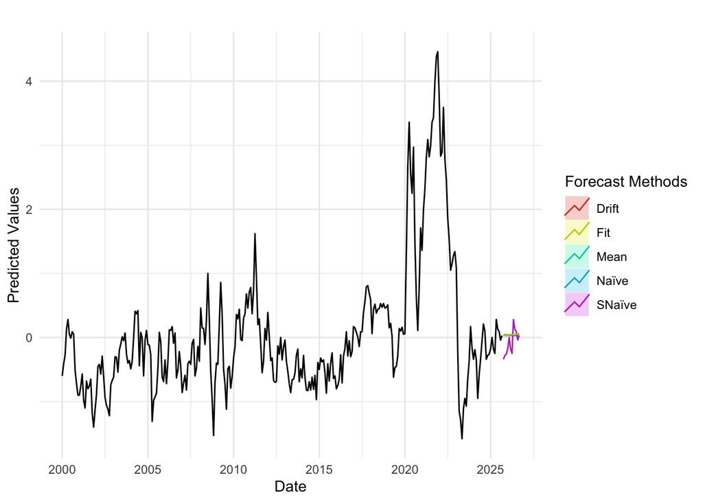

```r
fit <- Arima(gscpi_ts, order = c(0,1,0), include.drift = TRUE)
forecast_result <- forecast(fit, h = 12)
plot_forecasts(forecast_result, gscpi_ts, 12, fit)
```

**AHS Weighted Average Tariff**

```
                    ME      RMSE       MAE      MPE     MAPE      MASE
Training set 0.0250488 0.2718382 0.1789537 0.938805 3.703367 0.6006339
                    ACF1
Training set -0.02248871
```

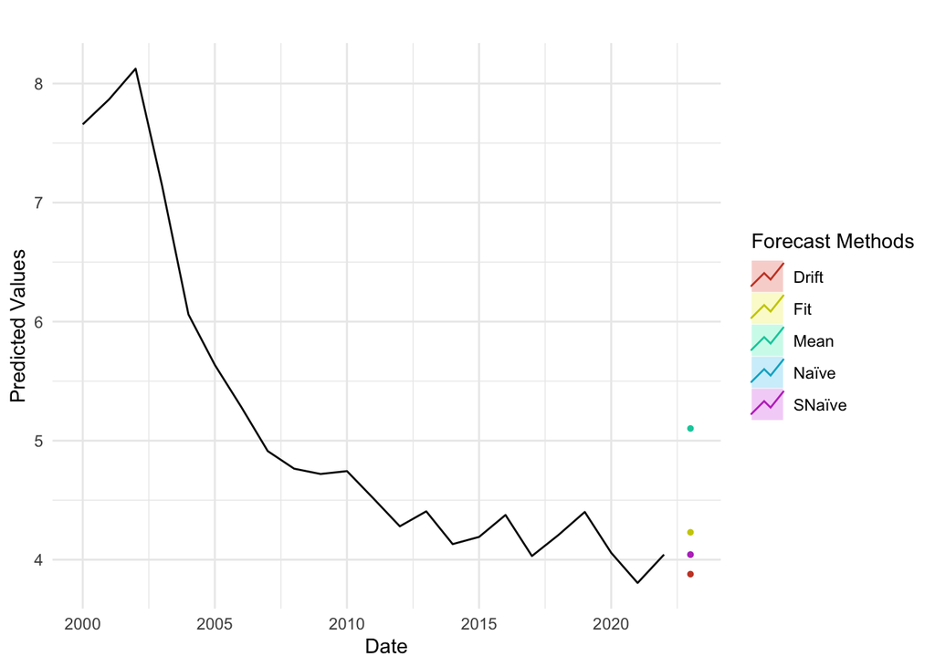

```r
fit <- Arima(ahs_ts, order = c(1,2,2), include.drift = TRUE)
forecast_result <- forecast(fit, h = 1)
plot_forecasts(forecast_result, ahs_ts, 1, fit)
```

**S&P 500 Index**

```
                      ME     RMSE      MAE       MPE     MAPE      MASE
Training set -0.05942576 157.8413 118.9505 -0.319068 3.384835 0.2224734
                     ACF1
Training set 0.0006927065
```

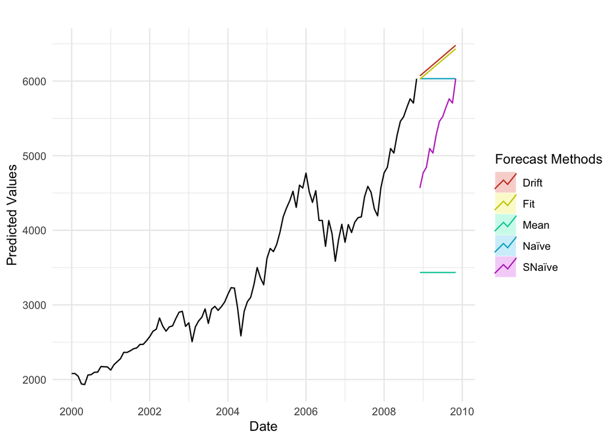

```r
fit <- Arima(sp500_ts, order = c(0,1,1), include.drift = TRUE)
forecast_result <- forecast(fit, h = 12)
plot_forecasts(forecast_result, sp500_ts, 12, fit)
```

**U.S. Retail & Food Services Sales**

```
                   ME     RMSE      MAE         MPE      MAPE      MASE
Training set 3.109955 8624.796 4034.006 -0.08910933 0.9403122 0.1825354
                   ACF1
Training set 0.00813901
```

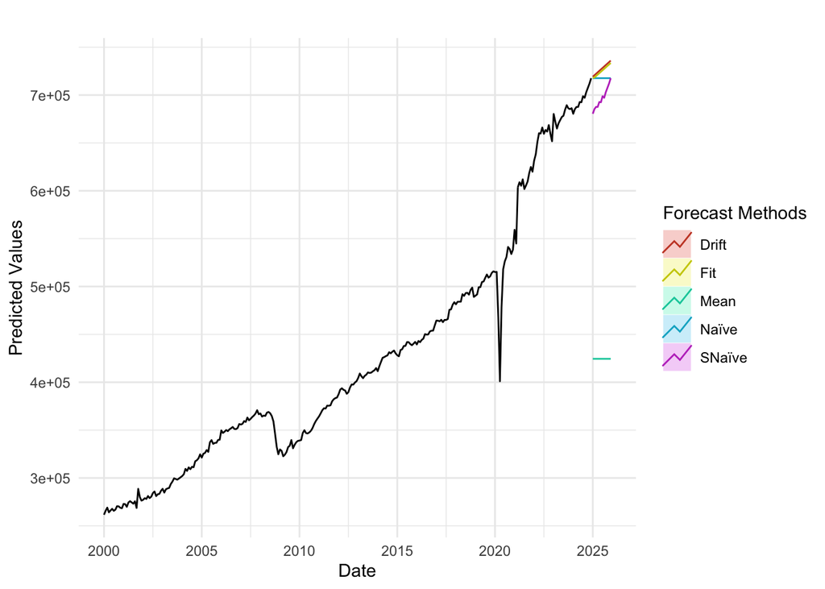

```r
fit <- Arima(rsafs_ts, order = c(0,1,2), include.drift = TRUE)
forecast_result <- forecast(fit, h = 12)
plot_forecasts(forecast_result, rsafs_ts, 12, fit)
```